# Regression Analysis

### Data

This database contains 14 physical attributes based on physical testing of a patient. Blood samples are taken and the patient also conducts a brief exercise test. The "goal" field refers to the presence of heart disease in the patient. It is integer (0 for no presence, 1 for presence). In general, to confirm 100% if a patient has heart disease can be quite an invasive process, so if we can create a model that accurately predicts the likelihood of heart disease, we can help avoid expensive and invasive procedures.

Content

Attribute Information:

Original Source: https://archive.ics.uci.edu/ml/datasets/Heart+Disease

### Importing All Neccessary Libraries

```python
import numpy as np # For arrays
import pandas as pd # Importing and manipulating the dataset
from matplotlib import pyplot as plt # For Plots
import seaborn as sns # For Creating Plots

from sklearn.preprocessing import StandardScaler # Standardized the Features of each column
from sklearn.model_selection import train_test_split # Split the dataset into test and train
from sklearn.linear_model import LinearRegression # To do Regression Analysis
from sklearn.linear_model import LogisticRegressionCV  # To do Classification
from sklearn.metrics import confusion_matrix,classification_report,plot_confusion_matrix # Evaluation Libraries to determine the performance of our model
from sklearn.preprocessing import LabelEncoder # Convert Categorical Data to Numerical Data

import warnings # Ignore any warnings
warnings.filterwarnings("ignore")
pd.options.display.max_columns = None #Allows us to view all the columns
```

#### Data Loading

```python
# load data from each csv files and assign new DataFrame names to each
# read excel file.
df1 = pd.read_csv('heart.csv')
df1.head() ### Viewing first 5 rows
```

|  | age | sex | cp | trestbps | chol | fbs | restecg | thalach | exang | oldpeak | slope | ca | thal | target |
| --- | --- | --- | --- | --- | --- | --- | --- | --- | --- | --- | --- | --- | --- | --- |
| 0 | 63 | 1 | 3 | 145 | 233 | 1 | 0 | 150 | 0 | 2.3 | 0 | 0 | 1 | 1 |
| 1 | 37 | 1 | 2 | 130 | 250 | 0 | 1 | 187 | 0 | 3.5 | 0 | 0 | 2 | 1 |
| 2 | 41 | 0 | 1 | 130 | 204 | 0 | 0 | 172 | 0 | 1.4 | 2 | 0 | 2 | 1 |
| 3 | 56 | 1 | 1 | 120 | 236 | 0 | 1 | 178 | 0 | 0.8 | 2 | 0 | 2 | 1 |
| 4 | 57 | 0 | 0 | 120 | 354 | 0 | 1 | 163 | 1 | 0.6 | 2 | 0 | 2 | 1 |

#### Data Exploration

```python
print(df1.shape) # Viewing Number of Rows and Columns
```

```
(303, 14)
```

```python
df1.info() #Viewing datatype and null values in dataset
```

```
<class 'pandas.core.frame.DataFrame'>
RangeIndex: 303 entries, 0 to 302
Data columns (total 14 columns):
 #   Column    Non-Null Count  Dtype
---  ------    --------------  -----
 0   age       303 non-null    int64
 1   sex       303 non-null    int64
 2   cp        303 non-null    int64
 3   trestbps  303 non-null    int64
 4   chol      303 non-null    int64
 5   fbs       303 non-null    int64
 6   restecg   303 non-null    int64
 7   thalach   303 non-null    int64
 8   exang     303 non-null    int64
 9   oldpeak   303 non-null    float64
 10  slope     303 non-null    int64
 11  ca        303 non-null    int64
 12  thal      303 non-null    int64
 13  target    303 non-null    int64
dtypes: float64(1), int64(13)
memory usage: 33.3 KB
```

```python
df1.describe(include='all').T #Showing Statistical Description of each column in the dataset
```

|  | count | mean | std | min | 25% | 50% | 75% | max |
| --- | --- | --- | --- | --- | --- | --- | --- | --- |
| age | 303.0 | 54.366337 | 9.082101 | 29.0 | 47.5 | 55.0 | 61.0 | 77.0 |
| sex | 303.0 | 0.683168 | 0.466011 | 0.0 | 0.0 | 1.0 | 1.0 | 1.0 |
| cp | 303.0 | 0.966997 | 1.032052 | 0.0 | 0.0 | 1.0 | 2.0 | 3.0 |
| trestbps | 303.0 | 131.623762 | 17.538143 | 94.0 | 120.0 | 130.0 | 140.0 | 200.0 |
| chol | 303.0 | 246.264026 | 51.830751 | 126.0 | 211.0 | 240.0 | 274.5 | 564.0 |
| fbs | 303.0 | 0.148515 | 0.356198 | 0.0 | 0.0 | 0.0 | 0.0 | 1.0 |
| restecg | 303.0 | 0.528053 | 0.525860 | 0.0 | 0.0 | 1.0 | 1.0 | 2.0 |
| thalach | 303.0 | 149.646865 | 22.905161 | 71.0 | 133.5 | 153.0 | 166.0 | 202.0 |
| exang | 303.0 | 0.326733 | 0.469794 | 0.0 | 0.0 | 0.0 | 1.0 | 1.0 |
| oldpeak | 303.0 | 1.039604 | 1.161075 | 0.0 | 0.0 | 0.8 | 1.6 | 6.2 |
| slope | 303.0 | 1.399340 | 0.616226 | 0.0 | 1.0 | 1.0 | 2.0 | 2.0 |
| ca | 303.0 | 0.729373 | 1.022606 | 0.0 | 0.0 | 0.0 | 1.0 | 4.0 |
| thal | 303.0 | 2.313531 | 0.612277 | 0.0 | 2.0 | 2.0 | 3.0 | 3.0 |
| target | 303.0 | 0.544554 | 0.498835 | 0.0 | 0.0 | 1.0 | 1.0 | 1.0 |

#### Data Preprocessing

```python
# Checking for any Duplicate Rows
dup_percentage = df1.duplicated().sum()/len(df1)*100
dup_percentage = round(dup_percentage,2)
dup_percentage = dup_percentage.astype(str) + '%'
dup_percentage
```

```
'0.33%'
```

```python
df1 = df1.drop_duplicates()
```

```python
# Confirming removal of duplicate rows
dup_percentage = df1.duplicated().sum()/len(df1)*100
dup_percentage = round(dup_percentage,2)
dup_percentage = dup_percentage.astype(str) + '%'
dup_percentage
```

```
'0.0%'
```

```python
# Checking for any missing values
missing = df1.isnull().sum()
missing
```

```
age         0
sex         0
cp          0
trestbps    0
chol        0
fbs         0
restecg     0
thalach     0
exang       0
oldpeak     0
slope       0
ca          0
thal        0
target      0
dtype: int64
```

```python
# Dealing with outliers in whole Dataset by removing upper and lower 1% percentile values
def cap_data(df):
    for col in df.columns:
        print("capping the ",col)
        if (((df[col].dtype)=='float64') | ((df[col].dtype)=='int64')):
            percentiles = df[col].quantile([0.01,0.99]).values
            df[col][df[col] <= percentiles[0]] = percentiles[0]
            df[col][df[col] >= percentiles[1]] = percentiles[1]
        else:
            df[col]=df[col]
    return df
```

```python
# Applying the function onto the dataset
df = cap_data(df1)
```

```
capping the  age
capping the  sex
capping the  cp
capping the  trestbps
capping the  chol
capping the  fbs
capping the  restecg
capping the  thalach
capping the  exang
capping the  oldpeak
capping the  slope
capping the  ca
capping the  thal
capping the  target
```

```python
# Resetting the index
df = df.reset_index(drop = True)
```

#### Data Visualization

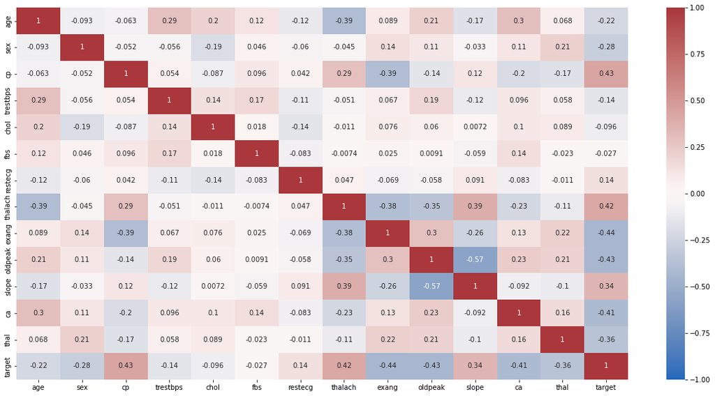

```python
# Viewing the correlation between features
plt.figure(figsize=(20, 10))
heatmap = sns.heatmap(df.corr(), vmin=-1, vmax=1, annot=True, cmap='vlag')
```

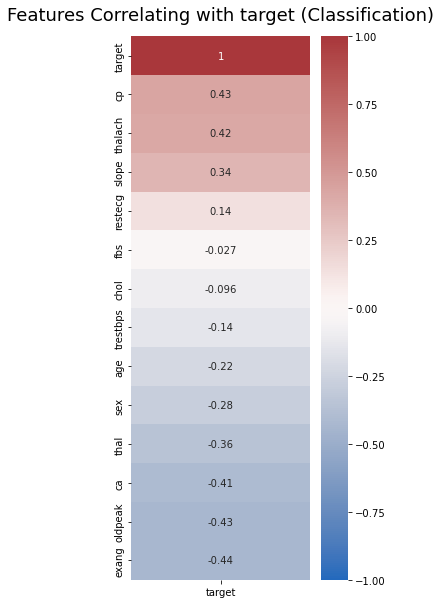

```python
plt.figure(figsize=(4, 10))
heatmap = sns.heatmap(df.corr()[['target']].sort_values(by='target', ascending=False), vmin=-1, vmax=1, annot=True, cmap='vlag')
heatmap.set_title('Features Correlating with target (Classification)', fontdict={'fontsize':18}, pad=16)
```

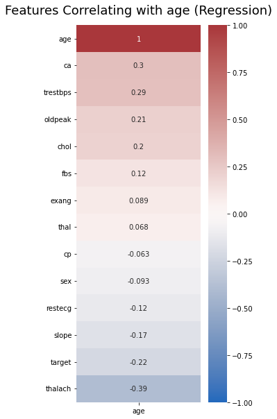

```python
plt.figure(figsize=(4, 10))
heatmap = sns.heatmap(df.corr()[['age']].sort_values(by='age', ascending=False), vmin=-1, vmax=1, annot=True, cmap='vlag')
heatmap.set_title('Features Correlating with age (Regression)', fontdict={'fontsize':18}, pad=16)
```

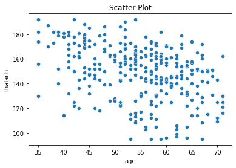

```python
sns.scatterplot(data=df, x="age", y="thalach") # Creating the scatterplot
plt.title('Scatter Plot') # Giving Scatterplot a title
plt.show() # Showing the updated plot
```

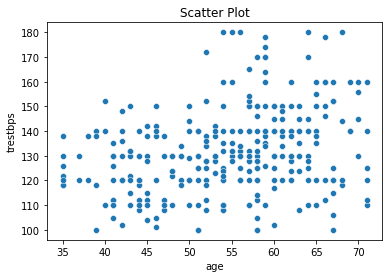

```python
sns.scatterplot(data=df, x="age", y="trestbps") # Creating the scatterplot
plt.title('Scatter Plot') # Giving Scatterplot a title
plt.show() # Showing the updated plot
```

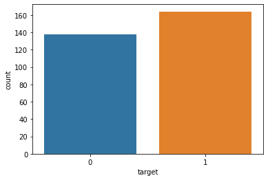

```python
sns.countplot(x='target',data=df1)
plt.show()
```

### Checking for Multicollinearity

```python
from statsmodels.stats.outliers_influence import variance_inflation_factor
```

```python
variables1 = df1.drop(['age','trestbps','thalach','chol','thal','slope'],axis=1)
vif1 = pd.DataFrame()
# here we make use of the variance_inflation_factor, which will basically output the respective VIFs
vif1["VIF"] = [variance_inflation_factor(variables1.values, i) for i in range(variables1.shape[1])]
# Finally, I like to include names so it is easier to explore the result
vif1["Features"] = variables1.columns
```

```python
vif1
```

|  | VIF | Features |
| --- | --- | --- |
| 0 | 2.541429 | sex |
| 1 | 2.472918 | cp |
| 2 | 1.230698 | fbs |
| 3 | 1.895754 | restecg |
| 4 | 1.758347 | exang |
| 5 | 2.055961 | oldpeak |
| 6 | 1.633926 | ca |
| 7 | 2.487789 | target |

## Multiple Linear Regression

### Declare the inputs and the targets

```python
# The target(s) (dependent variable) is 'age'
targets = df1['age']

# The inputs are everything BUT the dependent variable and high multicollinearity variables, so we can simply drop them
inputs = df1.drop(['age','trestbps','thalach','chol','thal','slope'],axis=1)
```

## Scale the Data

Feature scaling is a method used to normalize the range of independent variables or features of data. In data processing, it is also known as data normalization and is generally performed during the data preprocessing step.

```python
# Import the scaling module
from sklearn.preprocessing import StandardScaler

# Create a scaler object
scaler = StandardScaler()
# Fit the inputs (calculate the mean and standard deviation feature-wise)
scaler.fit(inputs)
```

```
StandardScaler()
```

```python
# Scale the features and store them in a new variable (the actual scaling procedure)
inputs_scaled = scaler.transform(inputs)
```

### The Importance of Data Splitting

- Supervised machine learning is about creating models that precisely map the given inputs (independent variables, or predictors) to the given outputs (dependent variables, or responses).
- How you measure the precision of your model depends on the type of a problem you’re trying to solve. In regression analysis, you typically use the coefficient of determination, root-mean-square error, mean absolute error, or similar quantities. For classification problems, you often apply accuracy, precision, recall, F1 score, and related indicators.
- Splitting your dataset is essential for an unbiased evaluation of prediction performance.
- Splitting a dataset might also be important for detecting if your model suffers from one of two very common problems, called underfitting and overfitting

### Underfitting and Overfitting

- Underfitting is usually the consequence of a model being unable to encapsulate the relations among data. For example, this can happen when trying to represent nonlinear relations with a linear model. Underfitted models will likely have poor performance with both training and test sets.
- Overfitting usually takes place when a model has an excessively complex structure and learns both the existing relations among data and noise. Such models often have bad generalization capabilities. Although they work well with training data, they usually yield poor performance with unseen (test) data.

### train_test_split(independant_variables,dependant_variable,test_size,train_size,random_state)

- train_size is the number that defines the size of the training set. If you provide a float, then it must be between 0.0 and 1.0 and will define the share of the dataset used for testing. If you provide an int, then it will represent the total number of the training samples. The default value is None.
- test_size is the number that defines the size of the test set. It’s very similar to train_size. You should provide either train_size or test_size. If neither is given, then the default share of the dataset that will be used for testing is 0.25, or 25 percent.
- random_state is the object that controls randomization during splitting. It can be either an int or an instance of RandomState. The default value is None.
- shuffle is the Boolean object (True by default) that determines whether to shuffle the dataset before applying the split.

```python
# Import the module for the split
from sklearn.model_selection import train_test_split

# Split the variables with an 80-20 split and some random state
# To have the same split as mine, use random_state = 365
x_train, x_test, y_train, y_test = train_test_split(inputs_scaled, targets, test_size=0.2, random_state=365)
```

### Create the regression

```python
# Create a linear regression object
reg = LinearRegression()
# Fit the regression with the scaled TRAIN inputs and targets
reg.fit(x_train,y_train)
```

```
LinearRegression()
```

- Let's check the outputs of the regression
- I'll store them in y_hat as this is the 'theoretical' name of the predictions

```python
y_hat = reg.predict(x_test)
```

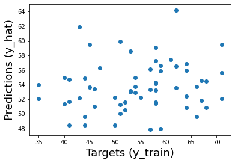

```python
plt.scatter(y_test, y_hat) #Scatterplot
plt.xlabel('Targets (y_train)',size=18) #Labelling X-Axis
plt.ylabel('Predictions (y_hat)',size=18) #Labelling Y-Axis
plt.show()
```

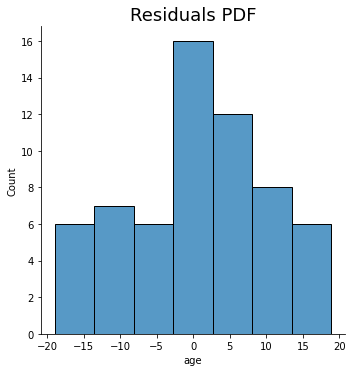

```python
sns.displot(y_test - y_hat)
plt.title("Residuals PDF", size=18) # Include a title
```

### Calculating R-Squared (Variance)

- Note that this is NOT the adjusted R-squared

```python
reg.score(x_train,y_train)
```

```
0.19944625064670984
```

### Calculate the Adjusted R-squared

Calculate the Adjusted R-squared

```python
def adj_r2(x,y):
    r2 = reg.score(x,y)
    n = x.shape[0]
    p = x.shape[1]
    adjusted_r2 = 1-(1-r2)*(n-1)/(n-p-1)
    return adjusted_r2
```

```python
adj_r2(x_train,y_train)
```

```
0.17184094894487223
```

```python
reg.intercept_
```

```
54.250806931076646
```

```python
reg.coef_
```

```
array([-1.67387421,  0.39934739,  1.02882321, -0.87987057,  0.44579178,
        0.54279763,  1.85314472, -1.80162454])
```

### Finding the weights (Cofficients of Regression)

- Note that they are barely interpretable if at all hence we create Regression Summary

**Continuous Values Interpretation:**

- **Postive Weight** shows that if a feature increases in value then so does the target
- **Negative Weight** shows that if a feature increases in value then target value decreases

```python
reg_summary = pd.DataFrame(inputs.columns.values, columns=['Features']) #inputs is the dataframe of independant variables
reg_summary['Weights'] = reg.coef_
reg_summary
```

|  | Features | Weights |
| --- | --- | --- |
| 0 | sex | -1.673874 |
| 1 | cp | 0.399347 |
| 2 | fbs | 1.028823 |
| 3 | restecg | -0.879871 |
| 4 | exang | 0.445792 |
| 5 | oldpeak | 0.542798 |
| 6 | ca | 1.853145 |
| 7 | target | -1.801625 |

## Logistic Regression

### Train | Test Split and Scaling

```python
X = df1.drop('target',axis=1)
y = df1['target']
```

```python
X_train, X_test, y_train, y_test = train_test_split(X, y, test_size=0.1, random_state=101)
```

```python
scaled_X_train = scaler.fit_transform(X_train)
scaled_X_test = scaler.transform(X_test)
```

### Creating Logistic Regression Model

```python
log_model = LogisticRegressionCV()
```

```python
log_model.fit(scaled_X_train,y_train)
```

```
LogisticRegressionCV()
```

### Visualizing the coefficients of Model

```python
coefs = pd.Series(index=X.columns,data=log_model.coef_[0])
```

```python
coefs = coefs.sort_values()
```

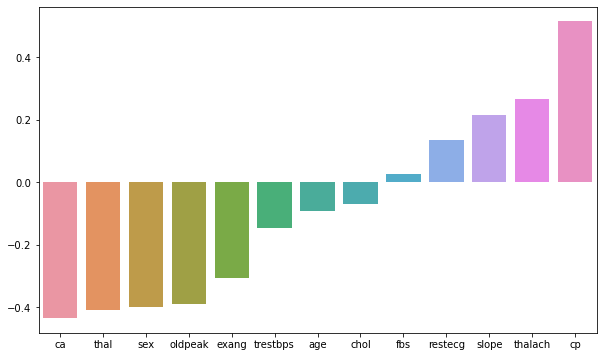

```python
plt.figure(figsize=(10,6))
sns.barplot(x=coefs.index,y=coefs.values);
```

### Making Predictions using trained model

```python
y_pred = log_model.predict(scaled_X_test)
```

## Evaluating the Model

### Plotting the Confusion Matrix

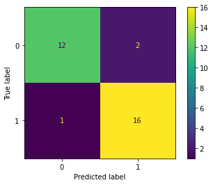

```python
# Shows how many values predictor got right and how many values it predicted wrong
plot_confusion_matrix(log_model,scaled_X_test,y_test)
plt.show()
```

```python
# Shows Overall performance of the model. We have a very good performance showing an accuracy of 90%
print(classification_report(y_test,y_pred))
```

```
              precision    recall  f1-score   support

           0       0.92      0.86      0.89        14
           1       0.89      0.94      0.91        17

    accuracy                           0.90        31
   macro avg       0.91      0.90      0.90        31
weighted avg       0.90      0.90      0.90        31
```

### Visualizing Precision and Recall Curve

```python
from sklearn.metrics import plot_precision_recall_curve,plot_roc_curve
```

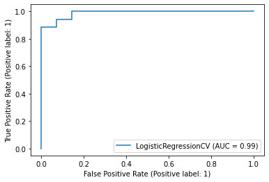

```python
plot_roc_curve(log_model,scaled_X_test,y_test)
plt.show()
```

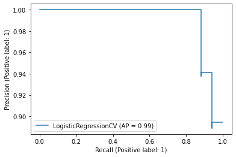

```python
plot_precision_recall_curve(log_model,scaled_X_test,y_test)
plt.show()
```